# **实验七**

## 实验目的

> 1. 了解Gradle部署工具，编写gradle静态检查任务staticAnalysys；
> 2. 配置代码规范检查工具checkstyle、pmd和spotbugs

## 实验前提

> 1.[gradle安装和配置](https://www.cnblogs.com/IcanFixIt/p/6909338.html)  
> 2.[checkstyle 插件](https://docs.gradle.org/current/dsl/org.gradle.api.plugins.quality.Checkstyle.html)  
> 3.[pmd插件](https://docs.gradle.org/current/userguide/pmd_plugin.html)  
> 4.[spotbugs插件](https://plugins.gradle.org/plugin/com.github.spotbugs) >

## 实验步骤

### 设置gradle参数

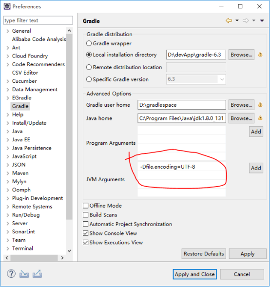

### 创建gradle工程

创建文件夹如果test06，在该文件夹进入cmd命名窗口，输入gradle init 生成java application 工程框架，选择Junit5测试框架

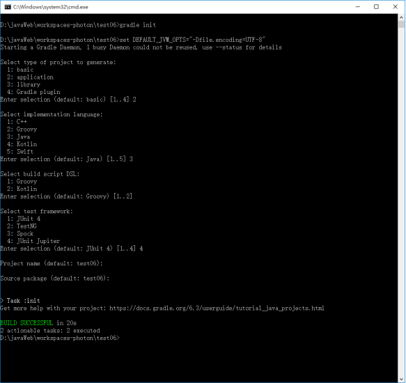

### 导入gradle工程

导入Eclipse或Intellj Idea；Eclipse安装buildship插件（最新版），便于设置gradle执行参数，以Eclipse为例：File>import>existing gradle project

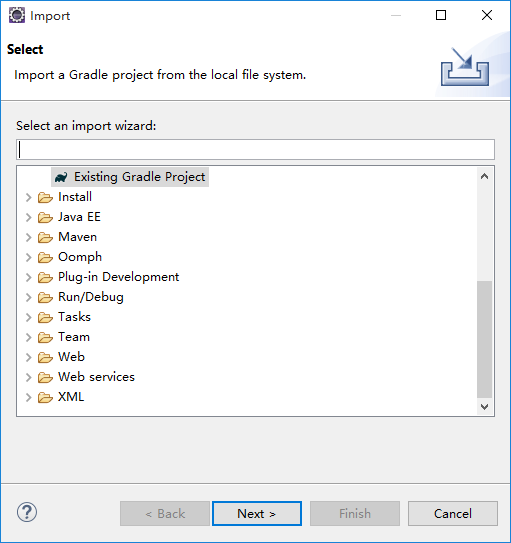

### 修改build.gradle

> 设置为阿里云的maven提高依赖jar包下载速度

[figure not shown]

```java
repositories {
    // Use jcenter for resolving dependencies.
    // You can declare any Maven/Ivy/file repository here.
    maven{ url 'http://maven.aliyun.com/nexus/content/groups/public/'}
}
```

### 加入测试代码

> 加入三角形问题代码以及测试代码

> 按照约定先于配置的原则放置代码 三角形问题生产代码：src/main/java  
> 测试用例代码： src/test/java  
> 测试资源：src/test/resources

[figure not shown]

> 可以看到测试代码中对于参数化测试代码出错，找不到params包，这是因为JUnit5把功能进行了分拆，向平台化发展的原因。 在build.gradle dependencies块中加入 params包,然后选择test06工程，右键菜单中选择gradle>refresh gradle project

```java
// Use JUnit Params for testing.
testImplementation 'org.junit.jupiter:junit-jupiter-params:5.6.0'
```